# Initial Data Anayysis - Project

Libraries

```r
library(tidyverse)
#install.packages("plotmo")
library(plotmo)
#install.packages("readxl")
library(readxl)
```

##Load the data

```r
jump_data <-read_excel("Jump_Data.xlsx")
```

##Cleaning data

Taking out columns that are not necessary

```r
sum(is.na(jump_data))
```

```
[1] 509
```

```r
#509 - column for body weight

jump_data <- jump_data[,-c(2,6)]
jump_data
```

| Athlete | Test Date | Body Weight [kg] | Trial | Flight Time:Contraction Time | Jump Height (Flight Time) in Inches [in] | Concentric Impulse [N s] | Eccentric Duration [ms] | Force at Zero Velocity [N] | Eccentric Deceleration RFD (Left) [N/s] | Eccentric Deceleration RFD (Right) [N/s] | Force at Zero Velocity (Left) [N] | Force at Zero Velocity (Right) [N] | P1 Concentric Impulse (Left) [N s] | P1 Concentric Impulse (Right) [N s] | P2 Concentric Impulse (Left) [N s] | P2 Concentric Impulse (Right) [N s] | RSI-modified [m/s] | Eccentric Deceleration RFD Asymmetry [% L,R] | Eccentric Peak Power / BM [W/kg] |
| --- | --- | --- | --- | --- | --- | --- | --- | --- | --- | --- | --- | --- | --- | --- | --- | --- | --- | --- | --- |
| 1 | 2023-09-11 07:39:45 | 56.19 | Trial 1 | 0.40 | 9.2 | 118.6 | 746 | 989 | 759 | 867 | 480 | 509 | 77.6 | 80.0 | 72.0 | 78.1 | 0.21 | 12.4 | 8.9 |
| 1 | 2023-09-11 07:39:45 | 56.19 | Trial 2 | 0.48 | 9.6 | 117.9 | 594 | 1009 | 898 | 828 | 495 | 514 | 81.0 | 78.7 | 78.2 | 70.7 | 0.26 | -7.7 | 10.6 |
| 1 | 2023-09-11 07:39:45 | 56.19 | Trial 3 | 0.42 | 9.1 | 117.3 | 651 | 932 | 773 | 599 | 465 | 467 | 80.9 | 77.9 | 78.6 | 85.4 | 0.23 | -22.6 | 9.8 |
| 1 | 2023-09-07 07:48:15 | 55.88 | Trial 1 | 0.46 | 9.7 | 118.8 | 640 | 977 | 826 | 924 | 464 | 513 | 74.4 | 80.5 | 70.8 | 81.1 | 0.25 | 10.6 | 9.0 |
| 1 | 2023-09-07 07:48:15 | 55.88 | Trial 2 | 0.41 | 9.8 | 121.9 | 723 | 933 | 779 | 695 | 464 | 469 | 80.9 | 81.0 | 82.2 | 87.7 | 0.23 | -10.7 | 8.1 |
| 1 | 2023-09-07 07:48:15 | 55.88 | Trial 3 | 0.37 | 10.0 | 122.6 | 814 | 801 | 397 | 225 | 415 | 386 | 86.7 | 80.7 | 90.9 | 98.2 | 0.20 | -43.4 | 7.7 |
| 1 | 2023-09-05 17:46:10 | 56.01 | Trial 1 | 0.47 | 10.0 | 122.3 | 608 | 941 | 790 | 798 | 475 | 466 | 80.4 | 72.0 | 85.3 | 85.1 | 0.26 | 0.9 | 9.5 |
| 1 | 2023-09-05 17:46:10 | 56.01 | Trial 2 | 0.45 | 10.4 | 124.7 | 680 | 988 | 990 | 803 | 502 | 486 | 81.7 | 75.6 | 79.4 | 80.1 | 0.26 | -18.9 | 8.5 |
| 1 | 2023-09-05 17:46:10 | 56.01 | Trial 3 | 0.43 | 10.6 | 126.3 | 707 | 1022 | 1012 | 926 | 517 | 505 | 83.2 | 83.0 | 78.1 | 88.0 | 0.25 | -8.5 | 9.2 |
| 1 | 2023-08-31 07:45:13 | 56.81 | Trial 1 | 0.44 | 9.9 | 123.2 | 685 | 891 | 514 | 562 | 421 | 470 | 76.6 | 77.7 | 76.8 | 77.1 | 0.25 | 8.6 | 7.6 |

[output cut: 499 more lines]

```r
sum(is.na(jump_data))
```

```
[1] 0
```

```r
#0
```

##Analysis

Making every athlete its own data set - to look for individual differences and looking at summary statistics for each

```r
athlete1 <- jump_data[c(19:51), ]
summary(athlete1$`Jump Height (Flight Time) in Inches [in]`)
```

```
   Min. 1st Qu.  Median    Mean 3rd Qu.    Max.
  9.100   9.600  10.000   9.942  10.300  10.900
```

```r
athlete2 <- jump_data[c(70:102), ]
summary(athlete2$`Jump Height (Flight Time) in Inches [in]`)
```

```
   Min. 1st Qu.  Median    Mean 3rd Qu.    Max.
  8.300   8.900   9.100   9.127   9.500  10.200
```

```r
athlete3 <- jump_data[c(120:152), ]
summary(athlete3$`Jump Height (Flight Time) in Inches [in]`)
```

```
   Min. 1st Qu.  Median    Mean 3rd Qu.    Max.
  10.20   11.20   12.10   12.03   12.70   13.70
```

```r
athlete4 <- jump_data[c(168:197), ]
summary(athlete4$`Jump Height (Flight Time) in Inches [in]`)
```

```
   Min. 1st Qu.  Median    Mean 3rd Qu.    Max.
  7.700   8.800   9.100   9.093   9.300  10.300
```

```r
athlete5 <- jump_data[c(225:251), ]
summary(athlete5$`Jump Height (Flight Time) in Inches [in]`)
```

```
   Min. 1st Qu.  Median    Mean 3rd Qu.    Max.
   6.10    6.85    7.50    7.57    8.30    9.00
```

```r
athlete6 <- jump_data[c(270:302), ]
summary(athlete6$`Jump Height (Flight Time) in Inches [in]`)
```

```
   Min. 1st Qu.  Median    Mean 3rd Qu.    Max.
   9.60   10.20   10.60   10.64   11.00   11.70
```

```r
#athlete 7 has one jump date we excluded since the weight was drastically different
athlete7 <- jump_data[c(321:338, 342:347), ]
summary(athlete7$`Jump Height (Flight Time) in Inches [in]`)
```

```
   Min. 1st Qu.  Median    Mean 3rd Qu.    Max.
   9.10    9.70   10.20   10.18   10.70   11.30
```

```r
athlete8 <- jump_data[c(369:398), ]
summary(athlete8$`Jump Height (Flight Time) in Inches [in]`)
```

```
   Min. 1st Qu.  Median    Mean 3rd Qu.    Max.
  10.80   11.43   11.75   11.73   11.97   12.60
```

```r
athlete9 <- jump_data[c(429:461), ]
summary(athlete9$`Jump Height (Flight Time) in Inches [in]`)
```

```
   Min. 1st Qu.  Median    Mean 3rd Qu.    Max.
  8.800   9.600   9.900   9.942  10.200  11.100
```

```r
athlete10 <- jump_data[c(480:509), ]
summary(athlete10$`Jump Height (Flight Time) in Inches [in]`)
```

```
   Min. 1st Qu.  Median    Mean 3rd Qu.    Max.
  6.500   7.800   8.000   7.993   8.275   9.100
```

##Visualization

Combining all athlete’s data into one new data set

```r
new_jump_data <- rbind(athlete1, athlete2, athlete3, athlete4, athlete5, athlete6, athlete7, athlete8, athlete9, athlete10)
```

```r
head(new_jump_data)
```

| Athlete | Test Date | Body Weight [kg] | Trial | Flight Time:Contraction Time | Jump Height (Flight Time) in Inches [in] | Concentric Impulse [N s] | Eccentric Duration [ms] | Force at Zero Velocity [N] | Eccentric Deceleration RFD (Left) [N/s] | Eccentric Deceleration RFD (Right) [N/s] | Force at Zero Velocity (Left) [N] | Force at Zero Velocity (Right) [N] | P1 Concentric Impulse (Left) [N s] | P1 Concentric Impulse (Right) [N s] | P2 Concentric Impulse (Left) [N s] | P2 Concentric Impulse (Right) [N s] | RSI-modified [m/s] | Eccentric Deceleration RFD Asymmetry [% L,R] | Eccentric Peak Power / BM [W/kg] |
| --- | --- | --- | --- | --- | --- | --- | --- | --- | --- | --- | --- | --- | --- | --- | --- | --- | --- | --- | --- |
| 1 | 2023-04-24 15:41:35 | 57.02 | Trial 1 | 0.42 | 9.8 | 119.2 | 722 | 1008 | 955 | 672 | 509 | 499 | 82.6 | 75.9 | 77.9 | 78.5 | 0.23 | -29.7 | 9.3 |
| 1 | 2023-04-24 15:41:35 | 57.02 | Trial 2 | 0.41 | 9.9 | 122.0 | 743 | 981 | 735 | 769 | 478 | 503 | 83.5 | 86.2 | 77.8 | 81.4 | 0.23 | 4.4 | 8.2 |
| 1 | 2023-04-24 15:41:35 | 57.02 | Trial 3 | 0.46 | 10.1 | 126.4 | 642 | 1092 | 1196 | 1198 | 554 | 538 | 85.6 | 86.1 | 74.4 | 79.3 | 0.26 | 0.2 | 9.8 |
| 1 | 2023-04-11 17:36:46 | 56.65 | Trial 1 | 0.48 | 10.4 | 128.0 | 619 | 1018 | 997 | 979 | 476 | 542 | 79.1 | 85.1 | 75.3 | 77.9 | 0.28 | -1.8 | 10.0 |
| 1 | 2023-04-11 17:36:46 | 56.65 | Trial 2 | 0.48 | 10.0 | 125.8 | 619 | 1074 | 1267 | 1324 | 522 | 552 | 76.7 | 80.2 | 69.5 | 78.9 | 0.27 | 4.3 | 9.5 |
| 1 | 2023-04-11 17:36:46 | 56.65 | Trial 3 | 0.47 | 10.0 | 124.1 | 622 | 1051 | 1315 | 1010 | 532 | 519 | 83.1 | 83.5 | 71.4 | 79.4 | 0.26 | -23.2 | 10.0 |

```r
#new_jump_data <- new_jump_data[nrow(new_jump_data):1,]

#names(new_jump_data) <- make.names(names(jump_data))

aths <- unique(new_jump_data[,c("Athlete", "Test Date")])

mean_diff_vec <- rep(NA, nrow(new_jump_data))

for(i in 2:nrow(new_jump_data)){
  if(new_jump_data$Athlete[i] == new_jump_data$Athlete[i-1] &
     new_jump_data$`Test Date`[i] != new_jump_data$`Test Date`[i-1]){

    #mean_diff_vec[i:(i+2)] <- new_jump_data$`Flight Time:Contraction Time`[i:(i+2)]/mean(new_jump_data$`Flight Time:Contraction Time`[(i-3):(i-1)], na.rm = TRUE)

     mean_diff_vec[i:(i+2)] <- new_jump_data$`Jump Height (Flight Time) in Inches [in]`[i:(i+2)]/mean(new_jump_data$`Jump Height (Flight Time) in Inches [in]`[(i-3):(i-1)], na.rm = TRUE)


  }
}

# for(i in 1:length(aths)){
#   mean_val <- mean(new_jump_data$`Flight Time:Contraction Time`[which(new)], na.rm = TRUE)
#
#
# }

new_jump_data$mean_diff_jump_height <- mean_diff_vec
```

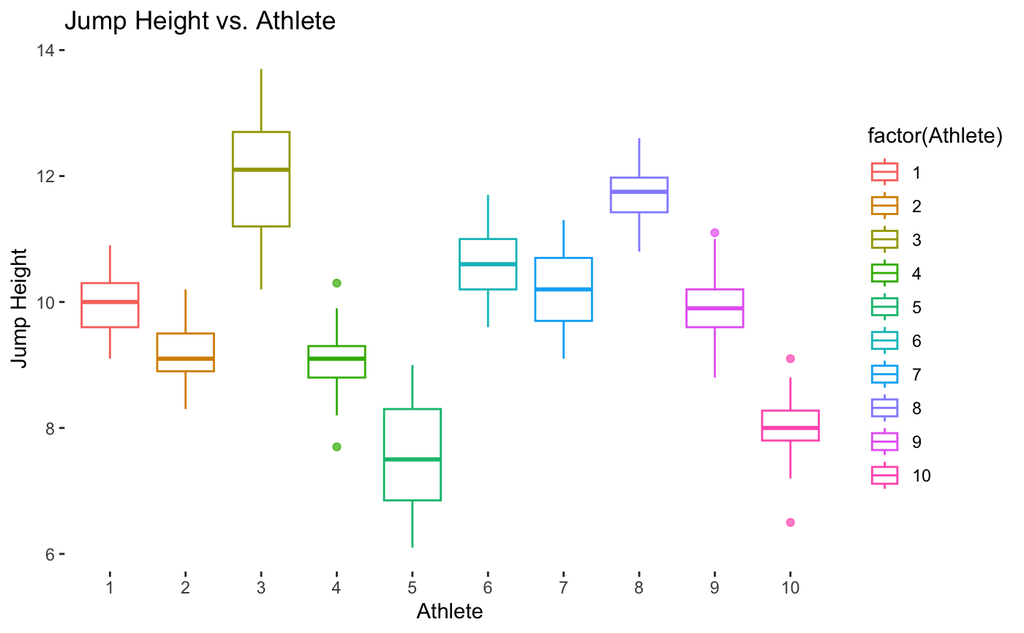

```r
 scatter_jump_height <- ggplot(new_jump_data,
              aes(y = `Jump Height (Flight Time) in Inches [in]`,
                  x = factor(Athlete),
                  color = factor(Athlete))) +
  geom_boxplot(alpha = 0.7) +
  theme_bw() +
  theme(panel.grid.major = element_blank(), # Turn of the background grid
        panel.grid.minor = element_blank(),
        panel.border = element_blank(),
        panel.background = element_blank()) +
  labs(y = "Jump Height",
       x = "Athlete",
       title = "Jump Height vs. Athlete")

scatter_jump_height
```

```r
scatter_peak_power <- ggplot(new_jump_data,
              aes(y = `Eccentric Peak Power / BM [W/kg]`,
                  x = factor(Athlete),
                  color = factor(Athlete))) +
  geom_boxplot(alpha = 0.7) +
  theme_bw() +
  theme(panel.grid.major = element_blank(), # Turn of the background grid
        panel.grid.minor = element_blank(),
        panel.border = element_blank(),
        panel.background = element_blank()) +
  labs(y = "Eccentric Peak Power",
       x = "Athlete",
       title = "Eccentric Peak Power vs. Athlete")

scatter_peak_power
```

```r
scatter_contraction_time <- ggplot(new_jump_data,
              aes(y = `Flight Time:Contraction Time`,
                  x = factor(Athlete),
                  color = factor(Athlete))) +
  geom_boxplot(alpha = 0.7) +
  theme_bw() +
  theme(panel.grid.major = element_blank(), # Turn of the background grid
        panel.grid.minor = element_blank(),
        panel.border = element_blank(),
        panel.background = element_blank()) +
  labs(y = "Flight Time : Contraction Time",
       x = "Athlete",
       title = "Flight Time:Contraction Time vs. Athlete")

scatter_contraction_time
```

###Choosing athletes 3 and 8 for further analysis ####Choosing athlete 10 for outliers to look at reliability

####Athlete 3

```r
athlete3_plot <- ggplot(athlete3,
              aes(y = `Jump Height (Flight Time) in Inches [in]`,
                  x = `Eccentric Peak Power / BM [W/kg]`,
                  color = `Trial`)) +
  geom_point(alpha = 0.3) +
  geom_smooth(method = "lm",se = FALSE ) +
  theme_bw() +
  theme(panel.grid.major = element_blank(),
        panel.grid.minor = element_blank(),
        panel.border = element_blank(),
        panel.background = element_blank()) +
  scale_color_manual(values =  c("Trial 1" = "blue", "Trial 2" = "red", "Trial 3" =  "green")) +
  labs(y = "Jump Height",
       x = "Eccentric Peak Power",
       color = "Trial",
       title = "Jump Height vs Eccentric Peak Power and Trial")

athlete3_plot
```

```r
athlete3_time <- ggplot(athlete3,
              aes(y = `Jump Height (Flight Time) in Inches [in]`,
                  x = `Test Date`,
                  color = `Trial`)) +
  geom_point(alpha = 0.3) +
  geom_smooth(method = "lm",se = FALSE ) +
  theme_bw() +
  theme(panel.grid.major = element_blank(),
        panel.grid.minor = element_blank(),
        panel.border = element_blank(),
        panel.background = element_blank()) +
  scale_color_manual(values =  c("Trial 1" = "blue", "Trial 2" = "red", "Trial 3" =  "green")) +
  labs(y = "Jump Height",
       x = "Test Date",
       color = "Trial",
       title = "Jump Height vs Test Date and Trial")

athlete3_time
```

####Athlete 8

```r
athlete8_plot <- ggplot(athlete8,
              aes(y = `Jump Height (Flight Time) in Inches [in]`,
                  x = `Eccentric Peak Power / BM [W/kg]`,
                  color = `Trial`)) +
  geom_point(alpha = 0.3) +
  geom_smooth(method = "lm",se = FALSE ) +
  theme_bw() +
  theme(panel.grid.major = element_blank(),
        panel.grid.minor = element_blank(),
        panel.border = element_blank(),
        panel.background = element_blank()) +
  scale_color_manual(values =  c("Trial 1" = "blue", "Trial 2" = "red", "Trial 3" =  "green")) +
  labs(y = "Jump Height",
       x = "Eccentric Peak Power",
       color = "Trial",
       title = "Jump Height vs Eccentric Peak Power and Trial")

athlete8_plot
```

```r
athlete8_time <- ggplot(athlete8,
              aes(y = `Jump Height (Flight Time) in Inches [in]`,
                  x = `Test Date`,
                  color = `Trial`)) +
  geom_point(alpha = 0.3) +
  geom_smooth(method = "lm",se = FALSE ) +
  theme_bw() +
  theme(panel.grid.major = element_blank(),
        panel.grid.minor = element_blank(),
        panel.border = element_blank(),
        panel.background = element_blank()) +
  scale_color_manual(values =  c("Trial 1" = "blue", "Trial 2" = "red", "Trial 3" =  "green")) +
  labs(y = "Jump Height",
       x = "Test Date",
       color = "Trial",
       title = "Jump Height vs Test Date and Trial")

athlete8_time
```

####Athlete 10

```r
athlete10_plot <- ggplot(athlete10,
              aes(y = `Jump Height (Flight Time) in Inches [in]`,
                  x = `Eccentric Peak Power / BM [W/kg]`,
                  color = `Trial`)) +
  geom_point(alpha = 0.3) +
  geom_smooth(method = "lm",se = FALSE ) +
  theme_bw() +
  theme(panel.grid.major = element_blank(),
        panel.grid.minor = element_blank(),
        panel.border = element_blank(),
        panel.background = element_blank()) +
  scale_color_manual(values =  c("Trial 1" = "blue", "Trial 2" = "red", "Trial 3" =  "green")) +
  labs(y = "Jump Height",
       x = "Eccentric Peak Power",
       color = "Trial",
       title = "Jump Height vs Eccentric Peak Power and Trial")

athlete10_plot
```

```r
athlete10_time <- ggplot(athlete10,
              aes(y = `Jump Height (Flight Time) in Inches [in]`,
                  x = `Test Date`,
                  color = `Trial`)) +
  geom_point(alpha = 0.3) +
  geom_smooth(method = "lm",se = FALSE ) +
  theme_bw() +
  theme(panel.grid.major = element_blank(),
        panel.grid.minor = element_blank(),
        panel.border = element_blank(),
        panel.background = element_blank()) +
  scale_color_manual(values =  c("Trial 1" = "blue", "Trial 2" = "red", "Trial 3" =  "green")) +
  labs(y = "Jump Height",
       x = "Test Date",
       color = "Trial",
       title = "Jump Height vs Test Date and Trial")

athlete10_time
```

Checking the correlation between the variables

```r
#install.packages("psych")
library(psych)
all_correlations <- cor.plot(cor(new_jump_data[,-c(1,2,4)],))
all_correlations

correlations3 <- as.data.frame(cor(athlete3[,-c(1,2,4)],))
correlations3

correlations8 <- as.data.frame(cor(athlete8[,-c(1,2,4)],))
correlations8

correlations10 <- as.data.frame(cor(athlete10[,-c(1,2,4)],))
correlations10
```

```r
install.packages("ggcorrplot")
```

```r
library(ggcorrplot)
```

```r
g_1 <- ggcorrplot(cor(new_jump_data[,-c(1,2,4)]))

ggsave(g_1, file = "corrplot.jpeg", width = 10, height = 10, dpi = 600)
```

```r
SST_JH_3 <- (athlete3$`Jump Height (Flight Time) in Inches [in]`) - mean(athlete3$`Jump Height (Flight Time) in Inches [in]`)
SST_JH_3

SST_JH_8 <- (athlete8$`Jump Height (Flight Time) in Inches [in]`) - mean(athlete8$`Jump Height (Flight Time) in Inches [in]`)
SST_JH_8


SST_JH_10 <- (athlete10$`Jump Height (Flight Time) in Inches [in]`) - mean(athlete10$`Jump Height (Flight Time) in Inches [in]`)
SST_JH_10
```

```r
SST_FTCT_3 <- (athlete3$`Flight Time:Contraction Time`) - mean(athlete3$`Flight Time:Contraction Time`)
SST_FTCT_3

SST_FTCT_8 <- (athlete8$`Flight Time:Contraction Time`) - mean(athlete8$`Flight Time:Contraction Time`)
SST_FTCT_8

SST_FTCT_10 <- (athlete10$`Flight Time:Contraction Time`) - mean(athlete10$`Flight Time:Contraction Time`)
SST_FTCT_10
```

Adding deviations to the data frame

```r
#adjust column names if we keep
athlete_3_temp <- athlete3
athlete_3_temp$SST_JH_3 <- SST_JH_3
athlete_3_temp$SST_FTCT_3 <- SST_FTCT_3

athlete_8_temp <- athlete8
athlete_8_temp$SST_JH_8 <- SST_JH_8
athlete_8_temp$SST_FTCT_8 <- SST_FTCT_8

athlete_10_temp <- athlete10
athlete_10_temp$SST_JH_10 <- SST_JH_10
athlete_10_temp$SST_FTCT_10 <- SST_FTCT_10
```

Athelte 3 - visualizations

```r
athlete3_time_deviation <- ggplot(athlete_3_temp,
              aes(y = `Jump Height (Flight Time) in Inches [in]`,
                  x = `Test Date`,
                  color = `SST_JH_3`)) +
  geom_point(alpha = 1) +
  geom_smooth(method = "lm",se = FALSE ) +
  theme_bw() +
  theme(panel.grid.major = element_blank(),
        panel.grid.minor = element_blank(),
        panel.border = element_blank(),
        panel.background = element_blank()) +
  scale_color_gradient(low = ("red"), high = ("green")) +
  labs(y = "Jump Height",
       x = "Test Date",
       color = "Fatigue",
       title = "Jump Height vs Test Date and Deviation")

athlete3_time_deviation
```

```r
deviation_plot_3 <- ggplot(athlete_3_temp,
              aes(y = `SST_JH_3`,
                  x = `Test Date`,
                  color = `Trial`)) +
  geom_point(alpha = 0.3) +
  geom_smooth(se = FALSE ) +
  theme_bw() +
  theme(panel.grid.major = element_blank(),
        panel.grid.minor = element_blank(),
        panel.border = element_blank(),
        panel.background = element_blank()) +
  scale_color_manual(values =  c("Trial 1" = "blue", "Trial 2" = "red", "Trial 3" =  "green")) +
  labs(y = "Difference from Average",
       x = "Test Date",
       color = "Trial",
       title = "Difference from Average vs Test Date and Trial")
deviation_plot_3
```

```r
previous.week.plot.athlete3 <- ggplot(new_jump_data[which(new_jump_data$Athlete == 3), ],
              aes(y = `mean_diff_jump_height`,
                  x = `Test Date`)) +

  geom_smooth(se = FALSE ) +
  theme_bw() +
  theme(panel.grid.major = element_blank(),
        panel.grid.minor = element_blank(),
        panel.border = element_blank(),
        panel.background = element_blank()) +
  labs(y = "Jump Height Difference",
       x = "Test Date",
       title = "Jump Height Difference from Previous Week vs Test Date ")
previous.week.plot.athlete3
```

Athlete 7 - Page is injured

```r
previous.week.plot.athlete7 <- ggplot(new_jump_data[which(new_jump_data$Athlete == 7), ],
              aes(y = `mean_diff_jump_height`,
                  x = `Test Date`)) +

  geom_smooth(se = FALSE ) +
  theme_bw() +
  theme(panel.grid.major = element_blank(),
        panel.grid.minor = element_blank(),
        panel.border = element_blank(),
        panel.background = element_blank()) +
  labs(y = "Jump Height Difference",
       x = "Test Date",
       title = "Jump Height Difference from Previous Week vs Test Date ")
previous.week.plot.athlete7
```

Athlete 8 - visualizations

```r
athlete8_time_deviation <- ggplot(athlete_8_temp,
              aes(y = `Jump Height (Flight Time) in Inches [in]`,
                  x = `Test Date`,
                  color = `SST_JH_8`)) +
  geom_point(alpha = 1) +
  geom_smooth(method = "lm",se = FALSE ) +
  theme_bw() +
  theme(panel.grid.major = element_blank(),
        panel.grid.minor = element_blank(),
        panel.border = element_blank(),
        panel.background = element_blank()) +
  scale_color_gradient(low = ("red"), high = ("green")) +
  labs(y = "Jump Height",
       x = "Test Date",
       color = "Fatigue",
       title = "Jump Height vs Test Date and Deviation")

athlete8_time_deviation
```

```r
deviation_plot_8 <- ggplot(athlete_8_temp,
              aes(y = `SST_JH_8`,
                  x = `Test Date`,
                  color = `Trial`)) +
  geom_point(alpha = 0.3) +
  geom_smooth(se = FALSE ) +
  theme_bw() +
  theme(panel.grid.major = element_blank(),
        panel.grid.minor = element_blank(),
        panel.border = element_blank(),
        panel.background = element_blank()) +
  scale_color_manual(values =  c("Trial 1" = "blue", "Trial 2" = "red", "Trial 3" =  "green")) +
  labs(y = "Difference from Average",
       x = "Test Date",
       color = "Trial",
       title = "Difference from Average vs Test Date and Trial")
deviation_plot_8
```

```r
previous.week.plot.athlete8 <- ggplot(new_jump_data[which(new_jump_data$Athlete == 8), ],
              aes(y = `mean_diff_jump_height`,
                  x = `Test Date`)) +

  geom_smooth(se = FALSE ) +
  theme_bw() +
  theme(panel.grid.major = element_blank(),
        panel.grid.minor = element_blank(),
        panel.border = element_blank(),
        panel.background = element_blank()) +
  labs(y = "Jump Height Difference",
       x = "Test Date",
       title = "Jump Height Difference from Previous Week vs Test Date ")
previous.week.plot.athlete8
```

Athlete 10 - visualizations

```r
athlete10_time_deviation <- ggplot(athlete_10_temp,
              aes(y = `Jump Height (Flight Time) in Inches [in]`,
                  x = `Test Date`,
                  color = `SST_JH_10`)) +
  geom_point(alpha = 1) +
  geom_smooth(method = "lm",se = FALSE ) +
  theme_bw() +
  theme(panel.grid.major = element_blank(),
        panel.grid.minor = element_blank(),
        panel.border = element_blank(),
        panel.background = element_blank()) +
  scale_color_gradient(low = ("red"), high = ("green")) +
  labs(y = "Jump Height",
       x = "Test Date",
       color = "Fatigue",
       title = "Jump Height vs Test Date and Deviation")

athlete10_time_deviation
```

```r
deviation_plot_10 <- ggplot(athlete_10_temp,
              aes(y = `SST_JH_10`,
                  x = `Test Date`,
                  color = `Trial`)) +
  geom_point(alpha = 0.3) +
  geom_smooth(se = FALSE ) +
  theme_bw() +
  theme(panel.grid.major = element_blank(),
        panel.grid.minor = element_blank(),
        panel.border = element_blank(),
        panel.background = element_blank()) +
  scale_color_manual(values =  c("Trial 1" = "blue", "Trial 2" = "red", "Trial 3" =  "green")) +
  labs(y = "Difference from Average",
       x = "Test Date",
       color = "Trial",
       title = "Difference from Average vs Test Date and Trial")
deviation_plot_10
```

```r
previous.week.plot.athlete10 <- ggplot(new_jump_data[which(new_jump_data$Athlete == 10), ],
              aes(y = `mean_diff_jump_height`,
                  x = `Test Date`)) +

  geom_smooth(se = FALSE ) +
  theme_bw() +
  theme(panel.grid.major = element_blank(),
        panel.grid.minor = element_blank(),
        panel.border = element_blank(),
        panel.background = element_blank()) +
  labs(y = "Jump Height Difference",
       x = "Test Date",
       title = "Jump Height Difference from Previous Week vs Test Date ")
previous.week.plot.athlete10
```

Prediction

Clustering - kmeans

Libraries

```r
#install.packages("devtools")
#library(devtools)
#library(xgboost)
#library(caret)
#library(ggplot2)
#library(xgboostExplainer)
#library(pROC)
#library(SHAPforxgboost)

#clustering libraries
library(tidyr)
library(cluster)
library(factoextra)
library(sparcl)
library(teamcolors)
library(ggimage)
library(ggdark)
```

Scaling

```r
scale_data <- scale(new_jump_data[,c(5:20)])

# Add categorical variables back to data frame
scale_data2 <- data.frame(scale_data)
scale_data2$Athlete <- new_jump_data$Athlete
scale_data2
```

cluster - kmeans 4 centers

```r
set.seed(12345)
fit_1 <- kmeans(x = scale_data2[,-17],
                centers = 4,
                nstart = 25,
                iter.max = 100 )

# Extract clusters
clusters_1 <- fit_1$cluster
# Extract centers
centers_1 <- fit_1$centers

summary(as.factor(clusters_1))
```

```r
cat("Cluster 1 teams:\n")
scale_data2$Athlete[clusters_1 == 1]
# Check teams in cluster 2
cat("Cluster 2 teams:\n")
scale_data2$Athlete[clusters_1== 2]
# Check teams in cluster 3
cat("Cluster 3 teams:\n")
scale_data2$Athlete[clusters_1 == 3]
# Check teams in cluster 4
cat("Cluster 4 teams:\n")
scale_data2$Athlete[clusters_1 == 4]
```

checking how many factors are in each cluster

```r
kmean_withinss <- function(k) {
  cluster <- kmeans( x = scale_data2[,-17],  # Set data to use
                    centers = k,  # Set number of clusters as k, changes with input into function
                    nstart = 25, # Set number of starts
                    iter.max = 100) # Set max number of iterations
  return (cluster$tot.withinss) # Return cluster error/within cluster sum of squares
}


# Set maximum cluster number
max_k <-20
# Run algorithm over a range of cluster numbers
wss <- sapply(2:max_k, kmean_withinss)


# Create a data frame to plot the graph
elbow <-data.frame(2:max_k, wss)

# Plot the graph with ggplot
g_e1 <- ggplot(elbow, # Set dataset
              aes(x = X2.max_k, y = wss)) + # Set aesthetics
  theme_set(theme_bw(base_size = 22) ) + # Set theme
  geom_point(color = "blue") + # Set geom point for scatter
  geom_line() + # Geom line for a line between points
  scale_x_continuous(breaks = seq(1, 20, by = 1)) + # Set breaks for x-axis
  labs(x = "Number of Clusters", y="Within Cluster \nSum of Squares") + # Set labels
  theme(panel.grid.major = element_blank(), # Turn of the background grid
        panel.grid.minor = element_blank(),
        panel.border = element_blank(),
        panel.background = element_blank())
# Generate plot
g_e1
```

[output not shown]

```r
set.seed(12345)
fit_2 <- kmeans(x = scale_data2[ ,-17],
                centers = 5,
                nstart = 25,
                iter.max = 100 )
# Extract clusters
clusters_2 <- fit_2$cluster
# Extract centers
centers_2 <- fit_2$centers
```

```r
cat("Cluster 1 teams:\n")
scale_data2$Athlete[clusters_2 == 1]
# Check teams in cluster 2
cat("Cluster 2 teams:\n")
scale_data2$Athlete[clusters_2 == 2]
# Check teams in cluster 3
cat("Cluster 3 teams:\n")
scale_data2$Athlete[clusters_2 == 3]
# Check teams in cluster 4
cat("Cluster 4 teams:\n")
scale_data2$Athlete[clusters_2 == 4]
# Check teams in cluster 5
cat("Cluster 5 teams:\n")
scale_data2$Athlete[clusters_2 == 5]
```

Checking cluster quality

Cardinality

```r
plot_clust_cardinality <- cbind.data.frame(clusters_1, clusters_2) # Join clusters with  k =4 and k=6

names(plot_clust_cardinality) <- c("k_4", "k_5") # Set names

# Create bar plots
g_2 <- ggplot(plot_clust_cardinality, aes( x = factor(k_4))) + # Set x as cluster values
  geom_bar(stat = "count", fill = "steelblue") + # Use geom_bar with stat = "count" to count observations
    labs(x = "Cluster Number", y="Points in Cluster", # Set labels
         title = "Cluster Cardinality (k = 4)") +
  theme(panel.grid.major = element_blank(), # Turn of the background grid
        panel.grid.minor = element_blank(),
        panel.border = element_blank(),
        panel.background = element_blank())


g_3 <- ggplot(plot_clust_cardinality, aes( x = factor(k_5))) + # Set x as cluster values
  geom_bar(stat = "count", fill = "steelblue") + # Use geom_bar with stat = "count" to count observations
    labs(x = "Cluster Number", y="Points in Cluster", # Set labels
         title = "Cluster Cardinality (k = 5)") +
  theme(panel.grid.major = element_blank(), # Turn of the background grid
        panel.grid.minor = element_blank(),
        panel.border = element_blank(),
        panel.background = element_blank())

# Generate bar plots
g_2
g_3
```

[output not shown]

Magnitude

```r
k_4_mag <- cbind.data.frame(c(1:4), fit_1$withinss) # Extract within cluster sum of squares

names(k_4_mag) <- c("cluster", "withinss") # Fix names for plot data


# Create bar plot
g_4 <- ggplot(k_4_mag, aes(x = cluster, y = withinss)) + # Set x as cluster, y as withinss
  geom_bar(stat = "identity", fill = "steelblue") + # Use geom bar and stat = "identity" to plot values directly
   labs(x = "Cluster Number", y="Total Point to Centroid Distance", # Set labels
         title = "Cluster Magnitude (k = 4)") +
  theme(panel.grid.major = element_blank(), # Turn of the background grid
        panel.grid.minor = element_blank(),
        panel.border = element_blank(),
        panel.background = element_blank())

k_5_mag <- cbind.data.frame(c(1:5), fit_2$withinss) # Extract within cluster sum of squares
names(k_5_mag) <- c("cluster", "withinss") # Fix names for plot data

# Create bar plot
g_5 <- ggplot(k_5_mag, aes(x = cluster, y = withinss)) +  # Set x as cluster, y as withinss
  geom_bar(stat = "identity", fill = "steelblue") + # Use geom bar and stat = "identity" to plot values directly
   labs(x = "Cluster Number", y="Total Point to Centroid Distance", # Set labels
         title = "Cluster Magnitude (k = 5)") +
  theme(panel.grid.major = element_blank(), # Turn of the background grid
        panel.grid.minor = element_blank(),
        panel.border = element_blank(),
        panel.background = element_blank())

# Generate plots
g_4
g_5
```

[output not shown]

```r
k_4_dat <- cbind.data.frame(table(clusters_1), k_4_mag[,2]) # Join magnitude and cardinality

names(k_4_dat) <- c("cluster", "cardinality", "magnitude") # Fix plot data names

# Create scatter plot
g_6 <- ggplot(k_4_dat, aes(x = cardinality, y = magnitude, color = cluster)) + # Set aesthetics
  geom_point(alpha = 0.8, size  = 4) +  # Set geom point for scatter
 geom_smooth(aes(x = cardinality, y = magnitude), method = "lm",
              se = FALSE, inherit.aes = FALSE, alpha = 0.5) + # Set trend  line
  labs(x = "Cluster Cardinality", y="Total Point to Centroid Distance", # Set labels
         title = "Cluster Magnitude vs Cardinality \n(k = 4)") +
  theme(panel.grid.major = element_blank(), # Turn of the background grid
        panel.grid.minor = element_blank(),
        panel.border = element_blank(),
        panel.background = element_blank())


k_5_dat <- cbind.data.frame(table(clusters_2), k_5_mag[,2]) # Join magnitude and cardinality

names(k_5_dat) <- c("cluster", "cardinality", "magnitude") # Fix plot data names

# Create scatter plot
g_7 <- ggplot(k_5_dat, aes(x = cardinality, y = magnitude, color = cluster)) + # Set aesthetics
  geom_point(alpha = 0.8, size = 4) +  # Set geom point for scatter
  geom_smooth(aes(x = cardinality, y = magnitude), method = "lm",
              se = FALSE, inherit.aes = FALSE, alpha = 0.5) + # Set trend  line
  labs(x = "Cluster Cardinality", y="Total Point to Centroid Distance", # Set labels
         title = "Cluster Magnitude vs Cardinality \n(k = 5)") +
  theme(panel.grid.major = element_blank(), # Turn of the background grid
        panel.grid.minor = element_blank(),
        panel.border = element_blank(),
        panel.background = element_blank())

# Generate scatter plots
g_6
g_7
```

[output not shown]

```r
# Create silhouette plot summary
fviz_nbclust(scale_data2[,-17], # Set dataset
             kmeans,# Set clustering method
             method = "silhouette", k.max = 20) # Set evaluation method
```

```r
# Create vector of clusters
cluster <- c(1: 4)
# Extract centers
center_df <- data.frame(cluster, centers_1)

# Reshape the data
center_reshape <- gather(center_df, features, values, Flight.Time.Contraction.Time:Eccentric.Peak.Power...BM..W.kg.)
# View first few rows
head(center_reshape)

# Create plot
g_heat_1 <- ggplot(data = center_reshape, # Set dataset
                   aes(x = features, y = cluster, fill = values)) + # Set aesthetics
  scale_y_continuous(breaks = seq(1, 4, by = 1)) + # Set y axis breaks
  geom_tile() + # Geom tile for heatmap
  coord_equal() +  # Make scale the same for both axis
  theme_set(theme_bw(base_size = 22) ) + # Set theme
  scale_fill_gradient2(low = "blue", # Choose low color
                       mid = "white", # Choose mid color
                       high = "red", # Choose high color
                       midpoint =0, # Choose mid point
                       space = "Lab",
                       na.value ="grey", # Choose NA value
                       guide = "colourbar", # Set color bar
                       aesthetics = "fill") + # Select aesthetics to apply
  coord_flip() # Rotate plot to view names clearly
# Generate plot
g_heat_1
```

Cluster - with previous week data

```r
pw.scale.data <- scale(new_jump_data[,c(5:21)])

# Add categorical variables back to data frame
pw.scale.data <- data.frame(pw.scale.data)
pw.scale.data$Athlete <- new_jump_data$Athlete
pw.scale.data <- na.omit(pw.scale.data)
pw.scale.data
```

```r
set.seed(12345)
fit_3 <- kmeans(x = pw.scale.data[,-18],
                centers = 4,
                nstart = 25,
                iter.max = 100 )

# Extract clusters
clusters_3 <- fit_3$cluster
# Extract centers
centers_3 <- fit_3$centers

summary(as.factor(clusters_3))
```

```r
cat("Cluster 1 teams:\n")
pw.scale.data$Athlete[clusters_3 == 1]
# Check teams in cluster 2
cat("Cluster 2 teams:\n")
pw.scale.data$Athlete[clusters_3== 2]
# Check teams in cluster 3
cat("Cluster 3 teams:\n")
pw.scale.data$Athlete[clusters_3 == 3]
cat("Cluster 1 teams:\n")
pw.scale.data$Athlete[clusters_3 == 4]
```

```r
# Create silhouette plot summary
fviz_nbclust(pw.scale.data[,-18], # Set dataset
             kmeans,# Set clustering method
             method = "silhouette", k.max = 20) # Set evaluation method
```

```r
kpw_4_mag <- cbind.data.frame(c(1:4), fit_3$withinss) # Extract within cluster sum of squares


kpw_4_dat <- cbind.data.frame(table(clusters_3), kpw_4_mag[,2]) # Join magnitude and cardinality

names(kpw_4_dat) <- c("cluster", "cardinality", "magnitude") # Fix plot data names

# Create scatter plot
g_8 <- ggplot(kpw_4_dat, aes(x = cardinality, y = magnitude, color = cluster)) + # Set aesthetics
  geom_point(alpha = 0.8, size = 4) +  # Set geom point for scatter
  geom_smooth(aes(x = cardinality, y = magnitude), method = "lm",
              se = FALSE, inherit.aes = FALSE, alpha = 0.5) + # Set trend  line
  labs(x = "Cluster Cardinality", y="Total Point to Centroid Distance", # Set labels
         title = "Cluster Magnitude vs Cardinality \n(k = 4)") +
  theme(panel.grid.major = element_blank(), # Turn of the background grid
        panel.grid.minor = element_blank(),
        panel.border = element_blank(),
        panel.background = element_blank())

g_8
```

```r
# Create vector of clusters
pw.cluster <- c(1: 4)
# Extract centers
pw.center_df <- data.frame(pw.cluster, centers_3)

# Reshape the data
pw.center_reshape <- gather(pw.center_df, features, values, Flight.Time.Contraction.Time:`mean_diff_jump_height`)
# View first few rows
head(pw.center_reshape)

# Create plot
g_heat_2 <- ggplot(data = pw.center_reshape, # Set dataset
                   aes(x = features, y = pw.cluster, fill = values)) + # Set aesthetics
  scale_y_continuous(breaks = seq(1, 4, by = 1)) + # Set y axis breaks
  geom_tile() + # Geom tile for heatmap
  coord_equal() +  # Make scale the same for both axis
  theme_set(theme_bw(base_size = 22) ) + # Set theme
  scale_fill_gradient2(low = "blue", # Choose low color
                       mid = "white", # Choose mid color
                       high = "red", # Choose high color
                       midpoint =0, # Choose mid point
                       space = "Lab",
                       na.value ="grey", # Choose NA value
                       guide = "colourbar", # Set color bar
                       aesthetics = "fill") + # Select aesthetics to apply
  coord_flip() # Rotate plot to view names clearly
# Generate plot
g_heat_2
```

XGBoost model

```r
install.packages("devtools")
library(devtools)
library(xgboost)
library(caret)
library(ggplot2)
#(xgboostExplainer)
library(pROC)
library(SHAPforxgboost)
```

```r
train.rows <- sample(rownames(new_jump_data),dim(new_jump_data)[1]*0.7)

# collect all the columns with training row ID into training set:
train_data <- new_jump_data[train.rows, ]

# assign row IDs that are not already in the training set, into validation
valid.rows <- setdiff(rownames(new_jump_data), train.rows)
test_data <- new_jump_data[valid.rows, ]
```

```r
#have to do as.numeric - 1 because it starts counting at 1 and we want 0,1
# Create training matrix
dtrain <- xgb.DMatrix(data = as.matrix(train_data[, 6:30]), label = train_data$`Jump Height (Flight Time) in Inches [in]`)
# Create test matrix
dtest <- xgb.DMatrix(data = as.matrix(test_data[, 6:30]), label = test_data$`Jump Height (Flight Time) in Inches [in]`)
```

# Predict Jump Height from given data

```r
set.seed(111111)
bst_1 <- xgboost(data = dtrain,
                 booster = "gblinear",

               nrounds = 100,

               verbose = 1,
                print_every_n = 20,

               eval_metric = "rmse")

summary(bst_1)
bst_1
```

```r
boost_preds_1 <- predict(bst_1, dtest)

#mean square error
mean((test_data$`Jump Height (Flight Time) in Inches [in]`-boost_preds_1)^2)

bst_1$evaluation_log

#mean absolute error
caret::MAE(test_data$`Jump Height (Flight Time) in Inches [in]`, boost_preds_1)

#RMSE
caret::RMSE(test_data$`Jump Height (Flight Time) in Inches [in]`, boost_preds_1)

#R squared
mean_test_1 <- mean(test_data$`Jump Height (Flight Time) in Inches [in]`)
tss = sum((test_data$`Jump Height (Flight Time) in Inches [in]` - mean_test_1)^2)

rss =  sum((test_data$`Jump Height (Flight Time) in Inches [in]` - boost_preds_1)^2)

rsq <- 1 - (rss/tss)
rsq
```

```r
reg <- lm(`Jump Height (Flight Time) in Inches [in]` ~ mean_diff_jump_height, data = new_jump_data, na.action = na.omit)
summary(reg)

reg2 <- lm(`Jump Height (Flight Time) in Inches [in]` ~ . -Athlete - `Test Date` - `Body Weight [kg]` - Trial , data = new_jump_data, na.action = na.omit)
summary(reg2)

reg3 <- lm(mean_diff_jump_height ~ . -Athlete - `Test Date` - `Body Weight [kg]` - Trial , data = new_jump_data, na.action = na.omit)
summary(reg3)
```

# Predict Next weeks Jump Height From Given Data

```r
train_data2 <- na.omit(train_data)
test_data2 <- na.omit(test_data)
# Create training matrix
dtrain2 <- xgb.DMatrix(data = as.matrix(train_data2[, -c(1:4, 28)]), label = train_data2$next_weeks_jump_height)
# Create test matrix
dtest2 <- xgb.DMatrix(data = as.matrix(test_data2[, -c(1:4, 28)]), label = test_data2$next_weeks_jump_height)


dtrain2 <- xgb.DMatrix(data = as.matrix(train_data[which(is.numeric(train_data$next_weeks_jump_height)), -c(1:4, 28)]), label = train_data$next_weeks_jump_height[which(is.numeric(train_data$next_weeks_jump_height))])
# Create test matrix
dtest2 <- xgb.DMatrix(data = as.matrix(test_data[which(is.numeric(test_data$next_weeks_jump_height)), -c(1:4, 28)]), label = test_data$next_weeks_jump_height[which(is.numeric(test_data$next_weeks_jump_height))])
```

```r
set.seed(111111)
bst_2 <- xgboost(data = dtrain2,
                 booster = "gblinear",

               nrounds = 100,

               verbose = 1,
                print_every_n = 20,

               eval_metric = "rmse")

summary(bst_2)
bst_2
```

```r
min(bst_2$evaluation_log$train_rmse)
```

```r
boost_preds_2 <- predict(bst_2, dtest2)

#mean square error
mean((test_data2$next_weeks_jump_height - boost_preds_2)^2)


#mean absolute error
caret::MAE(test_data2$next_weeks_jump_height, boost_preds_2)

#RMSE
caret::RMSE(test_data2$next_weeks_jump_height, boost_preds_2)

#R squared
mean_test_2 <- mean(test_data2$next_weeks_jump_height)
tss = sum((test_data2$next_weeks_jump_height - mean_test_2)^2)

rss =  sum((test_data2$next_weeks_jump_height - boost_preds_2)^2)

rsq <- 1 - (rss/tss)
rsq
```

Variable Importance

```r
# Extract importance
imp_mat <- xgb.importance(model = bst_2)
# Plot importance (top 10 variables)
xgb.plot.importance(imp_mat, top_n = 10)
```

```r
reg4 <- lm(next_weeks_jump_height ~ . -Athlete - `Test Date` - `Body Weight [kg]` - Trial, data = new_jump_data, na.action = na.omit)
summary(reg4)

reg5 <- lm(next_weeks_jump_height ~ mean_diff_flight_time + mean_diff_jump_height + mean_diff_concentric_impulse + mean_diff_eccentric_duration + mean_diff_force_zero + mean_diff_assymetry + mean_diff_peak_power, data = new_jump_data, na.action = na.omit)
summary(reg5)

reg6 <- lm(next_weeks_jump_height ~ flight_time_deviations + jump_height_deviations, data = new_jump_data, na.action = na.omit)
summary(reg6)

reg7 <- lm(next_weeks_jump_height ~ `Flight Time:Contraction Time`  + `Jump Height (Flight Time) in Inches [in]`, data = new_jump_data, na.action = na.omit)
summary(reg7)
```